# The Brand New RMarkdown Senior Thesis Template!

Chester Ismay (cismay@reed.edu)

Paideia 2k16 Slides available at http://rpubs.com/cismay/paideia_2k16_rmd

# Why this template was needed

## Traditional approach to writing a senior thesis involving statistical analysis

### The dreaded copy-and-paste

- Import data set into statistical software package
- Run the procedure to get results
- Copy and paste appropriate pieces from the analysis into document editor
- Add descriptions
- Finish/submit report

## Disadvantages of this process

- Lots of manual work (prone to make errors)
- Tedious (who likes to carefully copy-and-paste?)
- Likely not recordable (did you write down all the steps you followed to get your analysis?)
- What if you made an error at the beginning of your analysis? If your data had an error?

# Reproducible research

> “**Reproducible research** is the idea that data analyses, and more generally, scientific claims, are published with their data and software code so that others may verify the findings and build upon them.”
- Roger Peng, Johns Hopkins

## Why would reproducible research be of value with senior theses?

> “Let us change our traditional attitude to the construction of programs: Instead of imagining that our main task is to instruct a computer what to do, let us concentrate rather on explaining to humans what we want the computer to do.”
- Donald Knuth, *Literate Programming* (1984)

## What is Markdown?

- A “plaintext formatting syntax”
- Type in plain text, render to more complex formats
- One step beyond writing a `txt` file
- Render to HTML, PDF, etc.

## What does it look like?

```
  # Header 1

  ## Header 2

  Normal paragraphs of text go here.


  **I'm bold**

  [links!](http://rstudio.com)

   * Unordered
   * Lists

  And  Tables
  ---- -------
  Like This
```

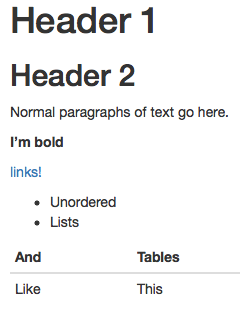

## What is RMarkdown?

- “Literate programming”
- Embed R code in a Markdown document
- Renders textual output along with graphics

````
```{r}
x <- rnorm(100)
length(x)
hist(x)
```
````

```
## [1] 100
```

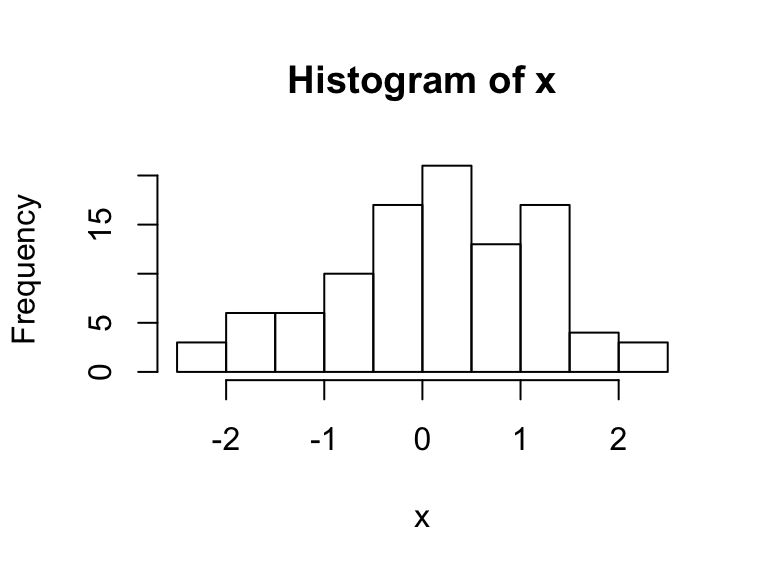

## But then I have to learn R…

## Tools to make working with R friendly

- RStudio is a powerful user interface that helps you get better control of your analysis.
- Like R, it is also completely free.
- You can write your entire paper/report (text, code, analysis, graphics, etc.) all in RMarkdown.
- If you need to update any of your code, RMarkdown will automatically update your plots and output of your analysis and will create an updated PDF file.
- **No more copy-and-paste!**
- It’s my job!

## What formats can RMarkdown output to?

[figure not shown]

# The Reed College RMarkdown Senior Thesis Template

## Using predefined templates

- The actual PDF that is produced via RMarkdown uses the existing $\LaTeX\,$ template
  - This is to keep the formatting to match what has been approved
- You don’t need to know any $\LaTeX\,$ to write your thesis now
  - Except for entering equations like $Y = mX + b$ which requires you to use the dollar signs
  - For example, `$Y = mX + b$`

# Demo of getting the template up-and-running

(Following along with blog [here](http://blogs.reed.edu/ed-tech/2015/11/r-markdown-senior-thesis-template/))

# What can I help you with?

- Data analysis
- Data wrangling/cleaning
- Data visualization
- Data tidying/manipulating
- Reproducible research

# When am I available?

- Email me at cismay@reed.edu or chester.ismay@reed.edu to schedule a time to meet if office hours don’t work
- Tentative Spring 2016 office (ETC 223) hours
  - Mondays (10 AM to 11 AM)
  - Tuesdays (2 PM to 3 PM)
  - Wednesdays (1:30 PM to 2:30 PM)
- Sometimes available for virtual office hours via Google Hangouts (email me for details)

# Resources

[Markdown Cheatsheet](https://github.com/adam-p/markdown-here/wiki/Markdown-Cheatsheet)

[R Markdown Reference Guide](https://www.rstudio.com/wp-content/uploads/2015/03/rmarkdown-reference.pdf)

[My `reedtemplates` package](https://github.com/ismayc/reedtemplates/)

# Thanks!

cismay@reed.edu

- [Blogpost about this thesis template](http://blogs.reed.edu/ed-tech/2015/11/r-markdown-senior-thesis-template/)
- Code for slide creation on [my GitHub page](https://github.com/ismayc/Reed_WoRkshops/tree/master/Paideia_Rmd_thesis_2016)
- Slides available [here](http://rpubs.com/cismay/paideia_2k16_rmd)